# Association rules

Bartłomiej Ramotowski

# Introduction

The goal of this project is to determine relations between sleep patterns, lifestyle choices and health metrics. Association rules helps us understand the complex connections in our dataset. We want to uncover valuable information that can guide people in sleeping better, making healthier choices, and feeling their best.

Link to kaggle data set: https://www.kaggle.com/datasets/uom190346a/sleep-health-and-lifestyle-dataset

Dataset Columns descriptions form Kaggle:

Dataset Columns descriptions form Kaggle:

Person ID: An identifier for each individual.

Gender: The gender of the person (Male/Female).

Age: The age of the person in years.

Occupation: The occupation or profession of the person.

Sleep Duration (hours): The number of hours the person sleeps per day.

Quality of Sleep (scale: 1-10): A subjective rating of the quality of sleep, ranging from 1 to 10.

Physical Activity Level (minutes/day): The number of minutes the person engages in physical activity daily.

Stress Level (scale: 1-10): A subjective rating of the stress level experienced by the person, ranging from 1 to 10.

BMI Category: The BMI category of the person (e.g., Underweight, Normal, Overweight).

Blood Pressure (systolic/diastolic): The blood pressure measurement of the person, indicated as systolic pressure over diastolic pressure.

Heart Rate (bpm): The resting heart rate of the person in beats per minute. Daily Steps: The number of steps the person takes per day.

Sleep Disorder: The presence or absence of a sleep disorder in the person (None, Insomnia, Sleep Apnea).

## Reading data

```r
health<-read.csv("Sleep_health_and_lifestyle_dataset.csv")
str(health)
```

```
## 'data.frame':    374 obs. of  13 variables:
##  $ Person.ID              : int  1 2 3 4 5 6 7 8 9 10 ...
##  $ Gender                 : chr  "Male" "Male" "Male" "Male" ...
##  $ Age                    : int  27 28 28 28 28 28 29 29 29 29 ...
##  $ Occupation             : chr  "Software Engineer" "Doctor" "Doctor" "Sales Representative" ...
##  $ Sleep.Duration         : num  6.1 6.2 6.2 5.9 5.9 5.9 6.3 7.8 7.8 7.8 ...
##  $ Quality.of.Sleep       : int  6 6 6 4 4 4 6 7 7 7 ...
##  $ Physical.Activity.Level: int  42 60 60 30 30 30 40 75 75 75 ...
##  $ Stress.Level           : int  6 8 8 8 8 8 7 6 6 6 ...
##  $ BMI.Category           : chr  "Overweight" "Normal" "Normal" "Obese" ...
##  $ Blood.Pressure         : chr  "126/83" "125/80" "125/80" "140/90" ...
##  $ Heart.Rate             : int  77 75 75 85 85 85 82 70 70 70 ...
##  $ Daily.Steps            : int  4200 10000 10000 3000 3000 3000 3500 8000 8000 8000 ...
##  $ Sleep.Disorder         : chr  "None" "None" "None" "Sleep Apnea" ...
```

```r
summary(health)
```

```
##    Person.ID         Gender               Age         Occupation
##  Min.   :  1.00   Length:374         Min.   :27.00   Length:374
##  1st Qu.: 94.25   Class :character   1st Qu.:35.25   Class :character
##  Median :187.50   Mode  :character   Median :43.00   Mode  :character
##  Mean   :187.50                      Mean   :42.18
##  3rd Qu.:280.75                      3rd Qu.:50.00
##  Max.   :374.00                      Max.   :59.00
##  Sleep.Duration  Quality.of.Sleep Physical.Activity.Level  Stress.Level
##  Min.   :5.800   Min.   :4.000    Min.   :30.00           Min.   :3.000
##  1st Qu.:6.400   1st Qu.:6.000    1st Qu.:45.00           1st Qu.:4.000
##  Median :7.200   Median :7.000    Median :60.00           Median :5.000
##  Mean   :7.132   Mean   :7.313    Mean   :59.17           Mean   :5.385
##  3rd Qu.:7.800   3rd Qu.:8.000    3rd Qu.:75.00           3rd Qu.:7.000
##  Max.   :8.500   Max.   :9.000    Max.   :90.00           Max.   :8.000
##  BMI.Category       Blood.Pressure       Heart.Rate     Daily.Steps
##  Length:374         Length:374         Min.   :65.00   Min.   : 3000
##  Class :character   Class :character   1st Qu.:68.00   1st Qu.: 5600
##  Mode  :character   Mode  :character   Median :70.00   Median : 7000
##                                        Mean   :70.17   Mean   : 6817
##                                        3rd Qu.:72.00   3rd Qu.: 8000
##                                        Max.   :86.00   Max.   :10000
##  Sleep.Disorder
##  Length:374
##  Class :character
##  Mode  :character
##
##
##
```

```r
health<-health[complete.cases(health), ]
```

### Columns

In this project, the prescription of right categories was crucial, as it establishes a strong foundation for use of the association rules alghorithms.

Variables categories are based on variable descriptions from Kaggle. I have also attached information about websites that I relied on while creating these categories.

#### Age

```r
summary(health$Age)
```

```
##    Min. 1st Qu.  Median    Mean 3rd Qu.    Max.
##   27.00   35.25   43.00   42.18   50.00   59.00
```

```r
health$Age =  ifelse(health$Age<18, "Age below 18",
              ifelse(health$Age<=24, "Age 18-24",
              ifelse(health$Age<=34, "Age 25-34",
              ifelse(health$Age<=44, "Age 35-44",
              ifelse(health$Age<=54, "Age 45-54",
              ifelse(health$Age<=64, "Age 55-64",
              ifelse(health$Age>=65, "Age 65 or above", NA)))))))
```

#### Sleep time

Sleep time in our data has min=5.8 and max=8.5 recommended sleep time for adults is 7-9 hourshttps://www.nhlbi.nih.gov/health/sleep/how-much-sleep In our data there are only adults.

```r
summary(health$Sleep.Duration)
```

```
##    Min. 1st Qu.  Median    Mean 3rd Qu.    Max.
##   5.800   6.400   7.200   7.132   7.800   8.500
```

```r
health$Sleep.Duration =  ifelse(health$Sleep.Duration<7, "Too short sleep",
                         ifelse(health$Sleep.Duration<=9, "Enought sleep",
                         ifelse(health$Sleep.Duration>9, "Too long sleep")))
```

#### Sleep Quality

```r
summary(health$Quality.of.Sleep)
```

```
##    Min. 1st Qu.  Median    Mean 3rd Qu.    Max.
##   4.000   6.000   7.000   7.313   8.000   9.000
```

```r
health$Quality.of.Sleep =  ifelse(health$Quality.of.Sleep<=4, "Low quality sleep",
                           ifelse(health$Quality.of.Sleep<=6, "Medium quality sleep",
                           ifelse(health$Quality.of.Sleep<=8, "Good quality sleep",
                           ifelse(health$Quality.of.Sleep>8, "Very good quality sleep",NA))))
```

#### Physical activity level

```r
summary(health$Physical.Activity.Level)
```

```
##    Min. 1st Qu.  Median    Mean 3rd Qu.    Max.
##   30.00   45.00   60.00   59.17   75.00   90.00
```

```r
health$Physical.Activity.Level =  ifelse(health$Physical.Activity.Level<=30, "Under 30 min of physical activity a day",
                                  ifelse(health$Physical.Activity.Level<=60, "30-60 min of physical activity a day",
                                  ifelse(health$Physical.Activity.Level>60, "Over 60 min of physical activity a day",NA)))
```

#### Stress level

```r
summary(health$Stress.Level)
```

```
##    Min. 1st Qu.  Median    Mean 3rd Qu.    Max.
##   3.000   4.000   5.000   5.385   7.000   8.000
```

```r
health$Stress.Level =  ifelse(health$Stress.Level<=2, "Very low stressed",
                       ifelse(health$Stress.Level<=4, "Low stressed",
                       ifelse(health$Stress.Level<=6, "Medium stressed",
                       ifelse(health$Stress.Level<=8, "Stressed",
                       ifelse(health$Stress.Level>8, "Very stressed",NA)))))
```

#### Blood Preasue

```r
summary(health$Blood.Pressure)
```

```
##    Length     Class      Mode
##       374 character character
```

#### Heart Rate (bpm):

The resting heart rate of the person in beats per minute. https://www.physio-pedia.com/Heart_Rate

```r
summary(health$Heart.Rate)
```

```
##    Min. 1st Qu.  Median    Mean 3rd Qu.    Max.
##   65.00   68.00   70.00   70.17   72.00   86.00
```

```r
health$Heart.Rate =  ifelse(health$Heart.Rate<=55, "Excellent heart rate",
                     ifelse(health$Heart.Rate<=65, "Good heart rate",
                     ifelse(health$Heart.Rate<=75, "Avrage heart rate",
                     ifelse(health$Heart.Rate<=85, "Poor heart rate",
                     ifelse(health$Heart.Rate>85, "Bad heart rate",NA)))))
```

#### Daily Steps

https://www.10000steps.org.au/articles/healthy-lifestyles/counting-steps/

```r
summary(health$Daily.Steps)
```

```
##    Min. 1st Qu.  Median    Mean 3rd Qu.    Max.
##    3000    5600    7000    6817    8000   10000
```

```r
health$Daily.Steps =  ifelse(health$Daily.Steps<=5000, "Sedentary daily steps",
                      ifelse(health$Daily.Steps<=7499, "Low daily steps",
                      ifelse(health$Daily.Steps<=9999, "Somewhat active daily steps",
                      ifelse(health$Daily.Steps<=12499, "Active daily steps",
                      ifelse(health$Daily.Steps>12500, "Highly active daily steps",NA)))))
```

#### BMI Category

```r
summary(health$BMI.Category)
```

```
##    Length     Class      Mode
##       374 character character
```

```r
unique(health$BMI.Category)
```

```
## [1] "Overweight"    "Normal"        "Obese"         "Normal Weight"
```

```r
health$BMI.Category = ifelse(health$BMI.Category=="Normal", "Normal weight",
                      ifelse(health$BMI.Category=="Overweight", "Overweight",
                      ifelse(health$BMI.Category=="Obese", "Obese",NA)))
```

#### Sleep disorder

```r
summary(health$Sleep.Disorder)
```

```
##    Length     Class      Mode
##       374 character character
```

```r
unique(health$Sleep.Disorder)
```

```
## [1] "None"        "Sleep Apnea" "Insomnia"
```

```r
health$Sleep.Disorder= ifelse(health$Sleep.Disorder=="None", "No sleep disorder",
                      ifelse(health$Sleep.Disorder=="Sleep Apnea", "Sleep Apnea",
                      ifelse(health$Sleep.Disorder=="Insomnia", "Insomnia",NA)))
```

### Saving the data

```r
health_clean=health[c(2:13)]
str(health_clean)
```

```
## 'data.frame':    374 obs. of  12 variables:
##  $ Gender                 : chr  "Male" "Male" "Male" "Male" ...
##  $ Age                    : chr  "Age 25-34" "Age 25-34" "Age 25-34" "Age 25-34" ...
##  $ Occupation             : chr  "Software Engineer" "Doctor" "Doctor" "Sales Representative" ...
##  $ Sleep.Duration         : chr  "Too short sleep" "Too short sleep" "Too short sleep" "Too short sleep" ...
##  $ Quality.of.Sleep       : chr  "Medium quality sleep" "Medium quality sleep" "Medium quality sleep" "Low quality sleep" ...
##  $ Physical.Activity.Level: chr  "30-60 min of physical activity a day" "30-60 min of physical activity a day" "30-60 min of physical activity a day" "Under 30 min of physical activity a day" ...
##  $ Stress.Level           : chr  "Medium stressed" "Stressed" "Stressed" "Stressed" ...
##  $ BMI.Category           : chr  "Overweight" "Normal weight" "Normal weight" "Obese" ...
##  $ Blood.Pressure         : chr  "126/83" "125/80" "125/80" "140/90" ...
##  $ Heart.Rate             : chr  "Poor heart rate" "Avrage heart rate" "Avrage heart rate" "Poor heart rate" ...
##  $ Daily.Steps            : chr  "Sedentary daily steps" "Active daily steps" "Active daily steps" "Sedentary daily steps" ...
##  $ Sleep.Disorder         : chr  "No sleep disorder" "No sleep disorder" "No sleep disorder" "Sleep Apnea" ...
```

```r
write.csv(health_clean, file = 'health_clean.csv')
```

## Association rules

```r
transactions = read.transactions('health_clean.csv', format='basket', sep=',', skip=0)
inspect(transactions[1:10])
```

```
##      items
## [1]  {Age,
##       Blood.Pressure,
##       BMI.Category,
##       Daily.Steps,
##       Gender,
##       Heart.Rate,
##       Occupation,
##       Physical.Activity.Level,
##       Quality.of.Sleep,
##       Sleep.Disorder,
##       Sleep.Duration,
##       Stress.Level}
## [2]  {1,
##       126/83,
##       30-60 min of physical activity a day,
##       Age 25-34,
##       Male,
##       Medium quality sleep,
##       Medium stressed,
##       No sleep disorder,
##       Overweight,
##       Poor heart rate,
##       Sedentary daily steps,
##       Software Engineer,
##       Too short sleep}
## [3]  {125/80,
##       2,
##       30-60 min of physical activity a day,
##       Active daily steps,
##       Age 25-34,
##       Avrage heart rate,
##       Doctor,
##       Male,
##       Medium quality sleep,
##       No sleep disorder,
##       Normal weight,
##       Stressed,
##       Too short sleep}
## [4]  {125/80,
```

[output cut: 75 more lines]

```
##       Over 60 min of physical activity a day,
##       Somewhat active daily steps}
## [10] {120/80,
##       9,
##       Age 25-34,
##       Avrage heart rate,
##       Doctor,
##       Enought sleep,
##       Good quality sleep,
##       Male,
##       Medium stressed,
##       No sleep disorder,
##       Normal weight,
##       Over 60 min of physical activity a day,
##       Somewhat active daily steps}
```

```r
size(transactions)
```

```
##   [1] 12 13 13 13 13 13 13 13 13 13 13 13 13 13 13 13 13 12 13 12 13 13 13 13 13
##  [26] 13 13 13 13 13 13 12 12 12 13 13 13 13 13 13 13 13 13 13 13 13 13 13 13 13
##  [51] 13 13 13 13 13 13 13 13 13 13 13 13 13 13 13 13 13 12 13 13 13 13 13 13 13
##  [76] 13 13 13 13 13 13 13 13 13 13 12 13 13 13 13 13 13 13 12 13 13 13 13 13 13
## [101] 13 13 13 13 13 13 13 13 12 12 13 13 13 13 13 13 13 13 13 13 13 13 13 13 13
## [126] 13 12 13 13 13 13 13 13 13 13 13 13 13 13 13 13 13 13 13 13 13 13 13 13 12
## [151] 12 12 13 13 13 13 13 13 13 13 13 13 12 12 13 13 13 12 13 13 13 13 13 13 13
## [176] 13 13 13 13 13 13 13 13 13 13 13 13 13 13 13 13 13 13 13 13 13 13 13 13 13
## [201] 13 13 13 13 12 13 13 13 13 13 13 13 13 13 13 13 13 13 13 13 13 13 13 13 13
## [226] 13 13 13 13 13 13 13 13 13 13 13 13 13 13 13 13 13 13 13 13 13 13 13 13 13
## [251] 13 13 13 13 13 13 13 13 13 13 13 13 13 13 13 13 13 13 13 13 13 13 13 13 13
## [276] 13 13 13 13 13 13 13 13 13 13 13 13 13 13 13 13 13 13 13 13 13 13 13 13 13
## [301] 13 13 13 12 13 13 13 13 13 13 13 13 13 13 13 13 13 13 13 13 13 13 13 13 13
## [326] 13 13 13 13 13 13 13 13 13 13 13 13 13 13 13 13 13 12 12 13 13 13 13 13 13
## [351] 13 13 13 13 13 13 13 13 13 13 13 13 13 13 13 13 13 13 13 13 13 13 13 13 13
```

```r
length(transactions)
```

```
## [1] 375
```

```r
round(itemFrequency(transactions),3) %>% sort(.,decreasing=T) %>% head(10)
```

```
##                    Avrage heart rate                        Enought sleep
##                                0.755                                0.584
##                    No sleep disorder                        Normal weight
##                                0.584                                0.520
##                                 Male                   Good quality sleep
##                                0.504                                0.496
##                               Female                            Age 35-44
##                                0.493                                0.448
## 30-60 min of physical activity a day                      Too short sleep
##                                0.435                                0.413
```

### Standard rules

```r
rules.transactions<-apriori(transactions, parameter=list(supp=0.1, conf=0.5))
```

```
## Apriori
##
## Parameter specification:
##  confidence minval smax arem  aval originalSupport maxtime support minlen
##         0.5    0.1    1 none FALSE            TRUE       5     0.1      1
##  maxlen target  ext
##      10  rules TRUE
##
## Algorithmic control:
##  filter tree heap memopt load sort verbose
##     0.1 TRUE TRUE  FALSE TRUE    2    TRUE
##
## Absolute minimum support count: 37
##
## set item appearances ...[0 item(s)] done [0.00s].
## set transactions ...[454 item(s), 375 transaction(s)] done [0.00s].
## sorting and recoding items ... [35 item(s)] done [0.00s].
## creating transaction tree ... done [0.00s].
## checking subsets of size 1 2 3 4 5 6 7 8 9 10
```

```
##  done [0.00s].
## writing ... [15624 rule(s)] done [0.00s].
## creating S4 object  ... done [0.01s].
```

```r
rules.transactionsSorted<-sort(rules.transactions, by="lift", decreasing=TRUE)
inspect(head(rules.transactionsSorted))
```

```
##     lhs                              rhs        support confidence  coverage     lift count
## [1] {Doctor,
##      Somewhat active daily steps} => {120/80} 0.1013333          1 0.1013333 8.333333    38
## [2] {Age 25-34,
##      Somewhat active daily steps} => {120/80} 0.1066667          1 0.1066667 8.333333    40
## [3] {Age 25-34,
##      Doctor,
##      Somewhat active daily steps} => {120/80} 0.1013333          1 0.1013333 8.333333    38
## [4] {Doctor,
##      Male,
##      Somewhat active daily steps} => {120/80} 0.1013333          1 0.1013333 8.333333    38
## [5] {Doctor,
##      Normal weight,
##      Somewhat active daily steps} => {120/80} 0.1013333          1 0.1013333 8.333333    38
## [6] {Avrage heart rate,
##      Doctor,
##      Somewhat active daily steps} => {120/80} 0.1013333          1 0.1013333 8.333333    38
```

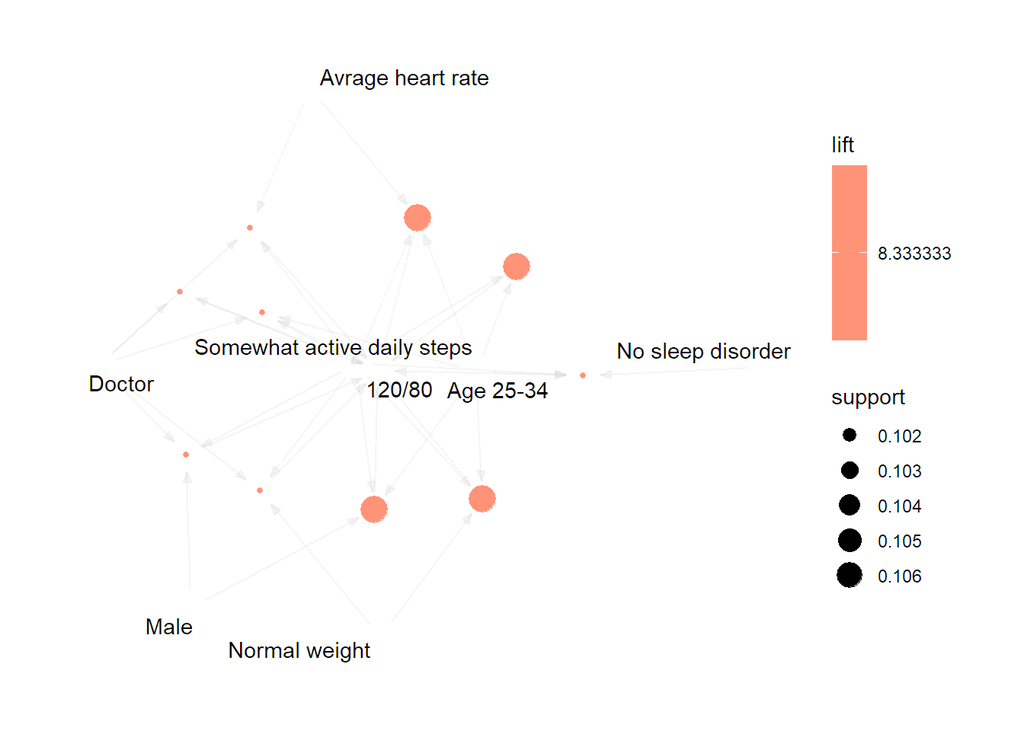

```r
rules_head <- head(rules.transactionsSorted,10)
plot(rules_head, method="graph", measure="support", shading="lift")
```

Now, let’s examine some basic rules to gain insights into individuals who are “stressed,” “overweight,” and have “insomnia.”

### Stressed rule

#### Right hand side (consequent)

```r
rulesStressed<-apriori(data=transactions, parameter=list(supp=0.1, conf=0.1), appearance=list(default="lhs", rhs="Stressed"), control=list(verbose=F))
rulesStressedSorted<-sort(rulesStressed, by="confidence", decreasing=TRUE)
inspect(head(rulesStressedSorted))
```

```
##     lhs                       rhs          support confidence  coverage  lift count
## [1] {Sleep Apnea,
##      Too short sleep}      => {Stressed} 0.1066667          1 0.1066667 3.125    40
## [2] {130/85,
##      Low daily steps}      => {Stressed} 0.1013333          1 0.1013333 3.125    38
## [3] {130/85,
##      Overweight}           => {Stressed} 0.1093333          1 0.1093333 3.125    41
## [4] {130/85,
##      Too short sleep}      => {Stressed} 0.1093333          1 0.1093333 3.125    41
## [5] {Avrage heart rate,
##      Medium quality sleep} => {Stressed} 0.2666667          1 0.2666667 3.125   100
## [6] {Avrage heart rate,
##      Insomnia,
##      Too short sleep}      => {Stressed} 0.1013333          1 0.1013333 3.125    38
```

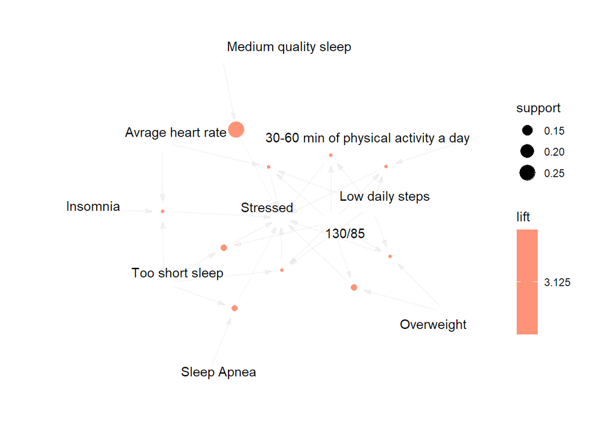

```r
rules_head <- head(rulesStressedSorted,10)
plot(rules_head, method="graph", measure="support", shading="lift")
```

People with sleep apnea or too short sleep are likely to be stressed. Similar associations exist for high blood pressure, low daily steps, overweight, and too short sleep.

#### Left hand side (antecedent)

```r
rulesStressed<-apriori(data=transactions, parameter=list(supp=0.1, conf=0.1), appearance=list(default="rhs", lhs="Stressed"), control=list(verbose=F))
rulesStressedSorted<-sort(rulesStressed, by="confidence", decreasing=TRUE)
inspect(head(rulesStressedSorted))
```

```
##     lhs           rhs                    support   confidence coverage lift
## [1] {Stressed} => {Too short sleep}      0.3200000 1.0000000  0.32     2.419355
## [2] {Stressed} => {Medium quality sleep} 0.2880000 0.9000000  0.32     3.013393
## [3] {Stressed} => {Avrage heart rate}    0.2826667 0.8833333  0.32     1.170495
## [4] {}         => {Avrage heart rate}    0.7546667 0.7546667  1.00     1.000000
## [5] {Stressed} => {Overweight}           0.2080000 0.6500000  0.32     1.646959
## [6] {Stressed} => {Male}                 0.1973333 0.6166667  0.32     1.223545
##     count
## [1] 120
## [2] 108
## [3] 106
## [4] 283
## [5]  78
## [6]  74
```

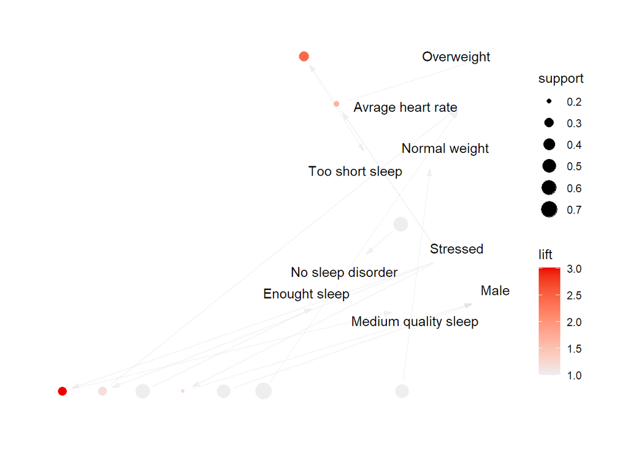

```r
rules_head <- head(rulesStressedSorted,10)
plot(rules_head, method="graph", measure="support", shading="lift")
```

These rules indicate relationships between stress and to short sleep, medium sleep quality,average heart rate, being overweight and being male.

### Overweight rule

#### Right hand side (consequent)

```r
rulesOverweight<-apriori(data=transactions, parameter=list(supp=0.1, conf=0.1), appearance=list(default="lhs", rhs="Overweight"), control=list(verbose=F))
rulesOverweightSorted<-sort(rulesOverweight, by="confidence", decreasing=TRUE)
inspect(head(rulesOverweightSorted))
```

```
##     lhs                                         rhs            support confidence  coverage     lift count
## [1] {140/95}                                 => {Overweight} 0.1733333          1 0.1733333 2.533784    65
## [2] {140/95,
##      Nurse}                                  => {Overweight} 0.1733333          1 0.1733333 2.533784    65
## [3] {140/95,
##      Sleep Apnea}                            => {Overweight} 0.1573333          1 0.1573333 2.533784    59
## [4] {140/95,
##      Over 60 min of physical activity a day} => {Overweight} 0.1733333          1 0.1733333 2.533784    65
## [5] {140/95,
##      Female}                                 => {Overweight} 0.1733333          1 0.1733333 2.533784    65
## [6] {140/95,
##      Avrage heart rate}                      => {Overweight} 0.1733333          1 0.1733333 2.533784    65
```

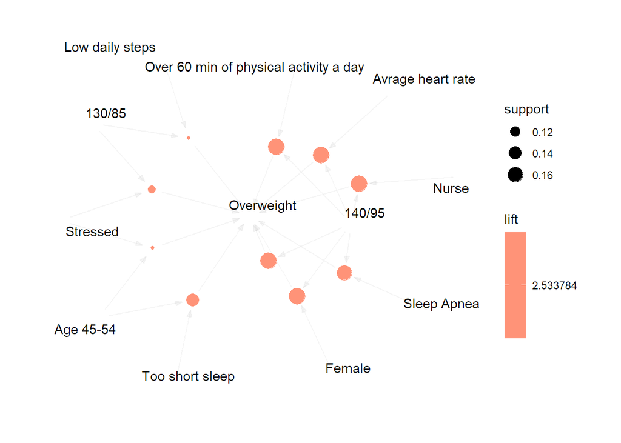

```r
rules_head <- head(rulesOverweightSorted,10)
plot(rules_head, method="graph", measure="support", shading="lift")
```

Haveing blood pressure of 140/95, being a nurse, having sleep apnea, engaging in over 60 minutes of daily physical activity, being female, or having an average heart rate are all linked to being overweight.

#### Left hand side (antecedent)

```r
rulesOverweight<-apriori(data=transactions, parameter=list(supp=0.1, conf=0.1), appearance=list(default="rhs", lhs="Overweight"), control=list(verbose=F))
rulesOverweightSorted<-sort(rulesOverweight, by="confidence", decreasing=TRUE)
inspect(head(rulesOverweightSorted))
```

```
##     lhs             rhs                 support   confidence coverage
## [1] {Overweight} => {Too short sleep}   0.2986667 0.7567568  0.3946667
## [2] {}           => {Avrage heart rate} 0.7546667 0.7546667  1.0000000
## [3] {Overweight} => {Avrage heart rate} 0.2960000 0.7500000  0.3946667
## [4] {Overweight} => {Low daily steps}   0.2826667 0.7162162  0.3946667
## [5] {Overweight} => {Female}            0.2826667 0.7162162  0.3946667
## [6] {}           => {No sleep disorder} 0.5840000 0.5840000  1.0000000
##     lift      count
## [1] 1.8308631 112
## [2] 1.0000000 283
## [3] 0.9938163 111
## [4] 1.8147370 106
## [5] 1.4517896 106
## [6] 1.0000000 219
```

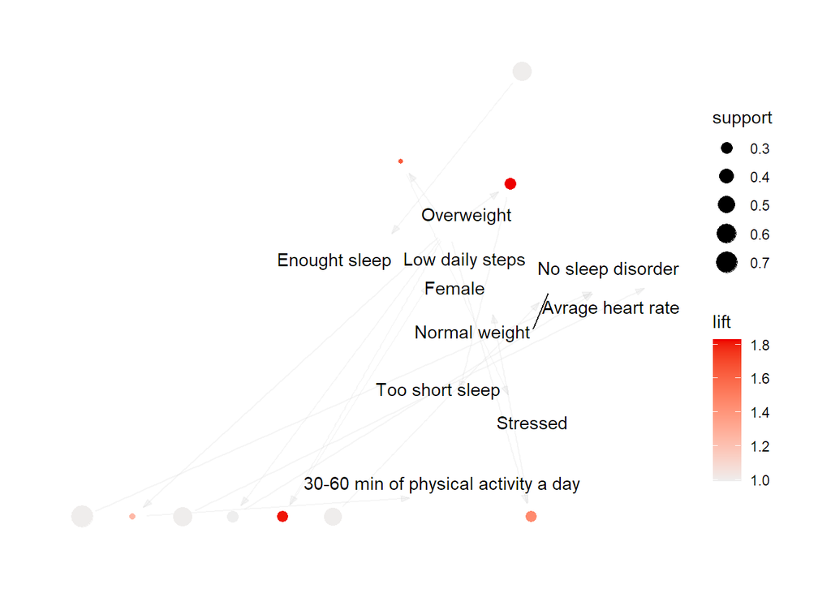

```r
rules_head <- head(rulesOverweightSorted,10)
plot(rules_head, method="graph", measure="support", shading="lift")
```

### Insomnia rule

#### Right hand side (consequent)

```r
rulesInsomnia<-apriori(data=transactions, parameter=list(supp=0.1, conf=0.1), appearance=list(default="lhs", rhs="Insomnia"), control=list(verbose=F))
rulesInsomniaSorted<-sort(rulesInsomnia, by="confidence", decreasing=TRUE)
inspect(head(rulesInsomniaSorted))
```

```
##     lhs                                        rhs          support confidence  coverage     lift count
## [1] {Age 35-44,
##      Low daily steps,
##      Overweight,
##      Too short sleep}                       => {Insomnia} 0.1146667  0.8958333 0.1280000 4.362825    43
## [2] {30-60 min of physical activity a day,
##      Age 35-44,
##      Low daily steps,
##      Overweight,
##      Too short sleep}                       => {Insomnia} 0.1146667  0.8958333 0.1280000 4.362825    43
## [3] {Age 35-44,
##      Low daily steps,
##      Too short sleep}                       => {Insomnia} 0.1146667  0.8600000 0.1333333 4.188312    43
## [4] {30-60 min of physical activity a day,
##      Age 35-44,
##      Low daily steps,
##      Overweight}                            => {Insomnia} 0.1146667  0.8600000 0.1333333 4.188312    43
## [5] {30-60 min of physical activity a day,
##      Age 35-44,
##      Low daily steps,
##      Too short sleep}                       => {Insomnia} 0.1146667  0.8600000 0.1333333 4.188312    43
## [6] {Age 35-44,
##      Low daily steps,
##      Overweight}                            => {Insomnia} 0.1146667  0.8431373 0.1360000 4.106188    43
```

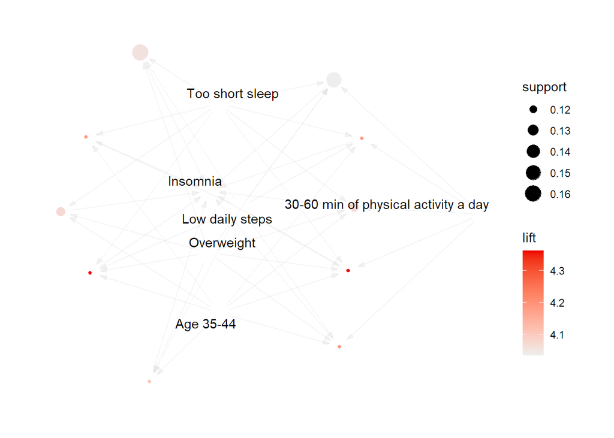

```r
rules_head <- head(rulesInsomniaSorted,10)
plot(rules_head, method="graph", measure="support", shading="lift")
```

Basing on results being 35-44 years old,low daily steps, overweight, and having too short sleep gives likelihood (89.6%) of experience insomnia.

#### Left hand side (antecedent)

```r
rulesInsomnia<-apriori(data=transactions, parameter=list(supp=0.1, conf=0.1), appearance=list(default="rhs", lhs="Insomnia"), control=list(verbose=F))
rulesInsomniaSorted<-sort(rulesInsomnia, by="confidence", decreasing=TRUE)
inspect(head(rulesInsomniaSorted))
```

```
##     lhs           rhs                                    support   confidence
## [1] {Insomnia} => {Too short sleep}                      0.1840000 0.8961039
## [2] {Insomnia} => {30-60 min of physical activity a day} 0.1760000 0.8571429
## [3] {Insomnia} => {Overweight}                           0.1706667 0.8311688
## [4] {Insomnia} => {Low daily steps}                      0.1626667 0.7922078
## [5] {}         => {Avrage heart rate}                    0.7546667 0.7546667
## [6] {Insomnia} => {Age 35-44}                            0.1360000 0.6623377
##     coverage  lift     count
## [1] 0.2053333 2.167993  69
## [2] 0.2053333 1.971954  66
## [3] 0.2053333 2.106002  64
## [4] 0.2053333 2.007283  61
## [5] 1.0000000 1.000000 283
## [6] 0.2053333 1.478432  51
```

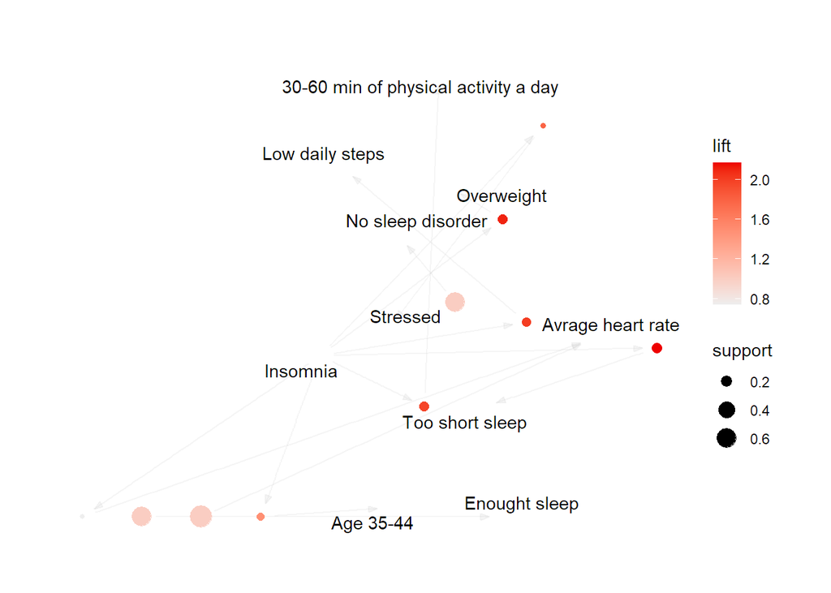

```r
rules_head <- head(rulesInsomniaSorted,10)
plot(rules_head, method="graph", measure="support", shading="lift")
```

## Conclusions

We successfully applied association rules to identify relationships among characteristics of various health variables. Furthermore, we analyzed individuals experiencing stress, being overweight, and having insomnia. This approach provided valuable insights into the health data.